# Series de tiempo y observaciones puntuales

Christian Salas-Eljatib, PhD

E-mail: cseljatib@gmail.com | Web: https://eljatib.com

Este código de R corresponde a la figura 6.15zz del libro **Análisis de datos con el programa estadístico R: una introducción aplicada** de Salas-Eljatib (2021).

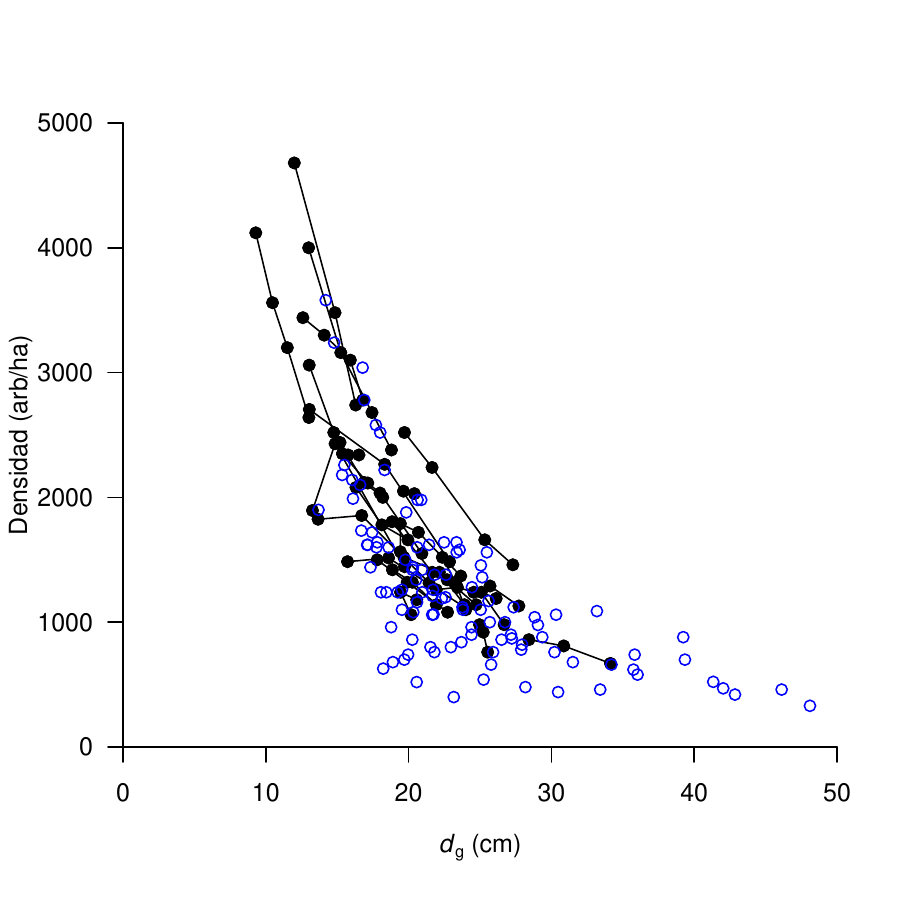

*Última actualización de esta web*: 13 noviembre, 2022

## Sobre esta figura

Este gráfico mezcla una serie de tiempo y mediciones puntuales (i.e., una sola medición). Una serie de tiempo se constituye por más de una medición de una variable aleatoria $Y$ para una unidad muestral en el tiempo. Sin embargo, en algunos estudios, si bien existen datos de series de tiempo, hay observaciones puntuales de las variable de interes en un sólo momento en el tiempo. Por ejemplo, Salas-Eljatib and Weiskittel (2018) mezclan datos de series de tiempo de las variables densidad y diámetro medio ($d_g$) de bosques en un grupo de unidades de muestreo permanentes, y datos puntuales en unidades no permanentes (i.e., donde no hay mediciones en el tiempo).

### Cargando los datos de ejemplo

Se ocuparán los objetos de datos plotpsptemp.RData que contiene las variables $N$ y $d_g$ en unidades de muestreo de bosques permanentes y temporales. Estos objetos se encuentran disponibles en el paquete *datana*. Los datos provienen del estudio de Salas-Eljatib and Weiskittel (2018).

```r
> library(datana)
> load("plotpsptemp.RData")
> head(psp)
```

[output not shown]

## El gráfico

Ahora procedemos a realizar el gráfico.

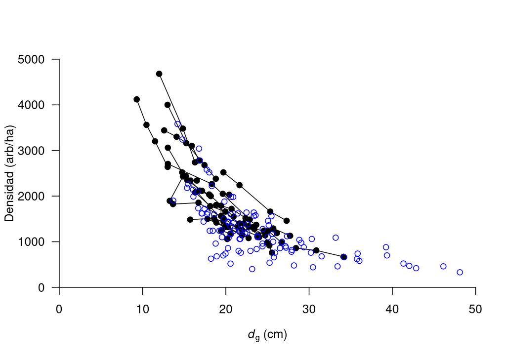

```r
> #obteniendo los valores de X e Y para mas adelante
> xvals <- split(psp$dg,psp$plot.id)
> yvals <- split(psp$nha,psp$plot.id)
> #primero: las series de tiempo
> plot(nha~dg,data=psp,
+      ylim=c(0,5000),xlim=c(0,50),
+      las=1,
+      yaxs="i", xaxs="i",
+      frame.plot = FALSE,
+      ylab = "Densidad (arb/ha)",
+      xlab=expression(paste(italic('d')[g],paste(" (cm)"))),
+      cex.lab=1)
> mapply(lines,xvals,yvals,type="o",col="black",pch=19)
> #segundo: las observaciones puntuales
> points(temp$nha~temp$dg,col="blue")
```

## Bibliografía

Salas-Eljatib, C. 2021. *Análisis de datos con el programa estadístico R: una introducción aplicada*. Santiago, Chile: Ediciones Universidad Mayor. https://tienda.zigzag.cl/9789566086109-analisis-de-datos-con-el-programa-estadistico-r.html.

Salas-Eljatib, C., and A. R. Weiskittel. 2018. “Evaluation of modeling strategies for assessing self-thinning behavior and carrying capacity.” *Ecology and Evolution* 8 (22): 10768–79. https://doi.org/10.1002/ece3.4525.